# Cardiotocography

Aleksandra Załęska

2023-01-03

Zbiór zawiera dane zebrane w czasie badań KTG płodów, parametry te zostały przeanalizowane przez trzech doświadczonych położników, a następnie na podstawie tych parametrów, położnicy nadali jedną z trzech możliwych klas dla każdego płodu świadczącą o jego stanie (1 = stan normalny, 2 = stan podejrzany, 3 = patologia płodu). Dane te są zawarte w ostatniej kolumnie NSP. Dokonano także klasyfikacji płodu (od 1 do 10) na podstawie wzorca morfologicznego, dane te są zawarte w kolumnie CLASS. Kolumna NSP jest zmienną kategoryczną o trzech poziomach i według mnie, jest ona główną kolumną modelowaną przez dane, żaś pozostałe kolumny dostarczają dodatkowych atrybutów danych.

Przyjrzyjmy się bliżej naszemu zbiorowi. Ładujemy dane do analizy:

```r
library(readr)
CTG <- read_csv("https://docs.google.com/spreadsheets/d/e/2PACX-1vSY8yoskQt0auIrvtbiu0oqdNF09DD8xCjA2rHTaSVqlmSGf_7heXlOT3-MtHkleiJ3ceD-H9ZSV35X/pub?gid=1248318734&single=true&output=csv")
```

#### Wartości brakujące

Po przejrzeniu danych możemy zauważyć, że w pierwszym wierszu oraz 3 ostatnich występują brakujące dane. Możemy usunąć te wiersze:

```r
CTG <- CTG[-c(1,2128:2130),]
```

#### Zbędne dane

Przeglądając zbiór danych możemy także zauważyć kolumy, które zawierają dane dla nas nieistotne takie jak nazwy plików, w których został zapisany wynik badania, daty badania itp., interesują nas zasadniczo tylko kolumny z parametrami otrzymanymi w czasie badania oraz klasyfikacją nadaną przez położników, czyli kolumny od LBE do NSP. Ponadto obie kolumny LBE i LB zawierają wyjściową wartość tętna płodu. Wartości te się powielają, wynika to z faktu iż, wartości zawarte w kolumnie LBE są pomiarami lekarza, natomiast wartości zawarte w kolumnie LB to pomiare generowane przez program. Możemy zatem pozostawić kolumnę LB, a kolumnę LBE usunąć.

```r
CTG <- CTG[, -c(1:6)]
```

#### Kontrola danych

Sprawdźmy jeszcze, czy nasze zmienne są odpowiedniego typu.

```r
str(CTG)
```

```
## tibble [2,126 × 34] (S3: tbl_df/tbl/data.frame)
##  $ LB      : num [1:2126] 120 132 133 134 132 134 134 122 122 122 ...
##  $ AC      : num [1:2126] 0 4 2 2 4 1 1 0 0 0 ...
##  $ FM      : num [1:2126] 0 0 0 0 0 0 0 0 0 0 ...
##  $ UC      : num [1:2126] 0 4 5 6 5 10 9 0 1 3 ...
##  $ ASTV    : num [1:2126] 73 17 16 16 16 26 29 83 84 86 ...
##  $ MSTV    : chr [1:2126] "0,5" "2,1" "2,1" "2,4" ...
##  $ ALTV    : num [1:2126] 43 0 0 0 0 0 0 6 5 6 ...
##  $ MLTV    : chr [1:2126] "2,4" "10,4" "13,4" "23" ...
##  $ DL      : num [1:2126] 0 2 2 2 0 9 6 0 0 0 ...
##  $ DS      : num [1:2126] 0 0 0 0 0 0 0 0 0 0 ...
##  $ DP      : num [1:2126] 0 0 0 0 0 2 2 0 0 0 ...
##  $ DR      : num [1:2126] 0 0 0 0 0 0 0 0 0 0 ...
##  $ Width   : num [1:2126] 64 130 130 117 117 150 150 68 68 68 ...
##  $ Min     : num [1:2126] 62 68 68 53 53 50 50 62 62 62 ...
```

[output cut: 20 more lines]

Wszystkie zmienne są typu numeric, zmienne Tendency, CLASS i NSP powinny być typu factor. Natomiast zmienne MSTV i MLTV są typu character, a powinny być typu numeric. Wynika to z faktu, iż zmienne MSTV i MLTV nie są całkowite, i użyto przecinka zamiast kropki. Zatem zanim zajmiemy się zmianą typu zmiennych, musimy zamienić przecinki na kropki w zmiennych MSTV i MLTV:

```r
library(stringr)
```

```r
CTG$MSTV <- str_replace_all(CTG$MSTV, ",", ".")
CTG$MLTV <- str_replace_all(CTG$MLTV, ",", ".")
```

Teraz zmieńmy typ zmiennych:

```r
CTG$NSP <- as.factor(CTG$NSP)
CTG$Tendency <- as.factor(CTG$Tendency)
CTG$CLASS <- as.factor(CTG$CLASS)
CTG$MSTV <- as.numeric(CTG$MSTV)
CTG$MLTV <- as.numeric(CTG$MLTV)
```

Możemy sprawdzić teraz czy wszystko się zgadza.

```r
str(CTG)
```

```
## tibble [2,126 × 34] (S3: tbl_df/tbl/data.frame)
##  $ LB      : num [1:2126] 120 132 133 134 132 134 134 122 122 122 ...
##  $ AC      : num [1:2126] 0 4 2 2 4 1 1 0 0 0 ...
##  $ FM      : num [1:2126] 0 0 0 0 0 0 0 0 0 0 ...
##  $ UC      : num [1:2126] 0 4 5 6 5 10 9 0 1 3 ...
##  $ ASTV    : num [1:2126] 73 17 16 16 16 26 29 83 84 86 ...
##  $ MSTV    : num [1:2126] 0.5 2.1 2.1 2.4 2.4 5.9 6.3 0.5 0.5 0.3 ...
##  $ ALTV    : num [1:2126] 43 0 0 0 0 0 0 6 5 6 ...
##  $ MLTV    : num [1:2126] 2.4 10.4 13.4 23 19.9 0 0 15.6 13.6 10.6 ...
##  $ DL      : num [1:2126] 0 2 2 2 0 9 6 0 0 0 ...
##  $ DS      : num [1:2126] 0 0 0 0 0 0 0 0 0 0 ...
##  $ DP      : num [1:2126] 0 0 0 0 0 2 2 0 0 0 ...
##  $ DR      : num [1:2126] 0 0 0 0 0 0 0 0 0 0 ...
##  $ Width   : num [1:2126] 64 130 130 117 117 150 150 68 68 68 ...
##  $ Min     : num [1:2126] 62 68 68 53 53 50 50 62 62 62 ...
```

[output cut: 20 more lines]

Wszystko jest już w porządku.

#### Opis kolumn

Mając już przygotowane dane do analizy, możemy przejść do opisu zawartości poszczególnych kolumn.

- LB zawiera wyjściowe wartości tętna płodu.
- AC zawiera ilość przyśpieszeń na sekundę.
- FM zawiera ilość ruchów płodu na sekundę.
- UC zawiera liczbę skurczów macicy na sekundę.
- DL zawiera liczba lekkich opóźnień na sekundę.
- DS zawiera liczba poważnych opóźnień na sekundę.
- DP zawiera liczba wydłużonych opóźnień na sekundę.
- ASTV zawiera procent czasu z nieprawidłową zmiennością krótkookresową.
- MSTV zawiera średnią wartość zmienności krótkookresowej.
- ALTV zawiera procent czasu z nieprawidłową długookresową zmiennością.
- MLTV zawiera średnią wartość zmienności długoterminowej.
- Width zawiera szerokość histogramu FHR.
- Min zawiera minimum histogramu FHR.
- Max zawiera maksimum histogramu FHR.
- Nmax zawiera liczbę szczytów histogramu.
- Nzero zawiera liczbę zer histogramu.
- Mode zawiera modę/dominantę histogramu.
- Mean zawiera średnią histogramu.
- Median zawiera medianę histogramu.
- Variance zawiera wariancję histogramu.
- Tendency zawiera tendencję histogramu (-1=asymetria lewostronna; 0=symetria; 1= asymetria prawostronna).
- CLASS - kod klasy wzoru FHR (od 1 do 10).
- NSP - kod klasy stanu płodu (1=normalny; 2=podejrzany; 3=patologia płodu).

Możemy teraz przedstawić te poszczególne parametry z podziałem na stan płodu i porównać je ze sobą. W ten sposób będziemy mogli określić jakie parametry determinują stan płodu zagrażający życiu. Ale najpierw sprawdźmy jak dużo jest płodów w poszczególnych stanach i jak duży odsetek stanowią płody zagrożone.

```r
#ustalmy ramki danych dla tych trzech kategorii stanu płodu:
normal_fetal_state <- subset(CTG, CTG$NSP == 1)
suspect_fetal_state <- subset(CTG, CTG$NSP == 2)
pathologic_fetal_state <- subset(CTG, CTG$NSP == 3)
```

```r
#ilośc płodów w poszczególnych kategoriach
num_of_normal_fetal <- nrow(normal_fetal_state)
num_of_suspect_fetal <- nrow(suspect_fetal_state)
num_of_pathologic_fetal <- nrow(pathologic_fetal_state)
```

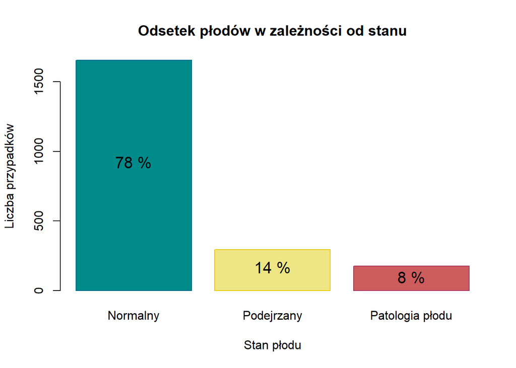

```r
barplot(c(num_of_normal_fetal, num_of_suspect_fetal,num_of_pathologic_fetal), names = c("Normalny", "Podejrzany", "Patologia płodu"), xlab = "Stan płodu", ylab = "Liczba przypadków", col=c("darkcyan", "khaki2", "indianred"), border=c("deepskyblue4","gold2","maroon"), main = "Odsetek płodów w zależności od stanu")
text(0.7, (num_of_normal_fetal/2), paste( round((num_of_normal_fetal/nrow(CTG))*100),"%"), pos=3, cex=1.3)
text(1.9, (num_of_suspect_fetal/4), paste( round((num_of_suspect_fetal/nrow(CTG))*100),"%"), pos=3, cex=1.3)
text(3.1, (num_of_pathologic_fetal/500), paste( round((num_of_pathologic_fetal/nrow(CTG))*100),"%"), pos=3, cex=1.3)
```

Patrząc na powyższy wykres, możemy zauważyć, że odsetek płodów znajdujących się w stanie “podejrzany” lub “patologia płodu” jest dość duży.

Sprawdźmy zatem jak wygląda porównanie pozostałych parametrów dla poszczególnych stanów:

```r
library("vioplot")
```

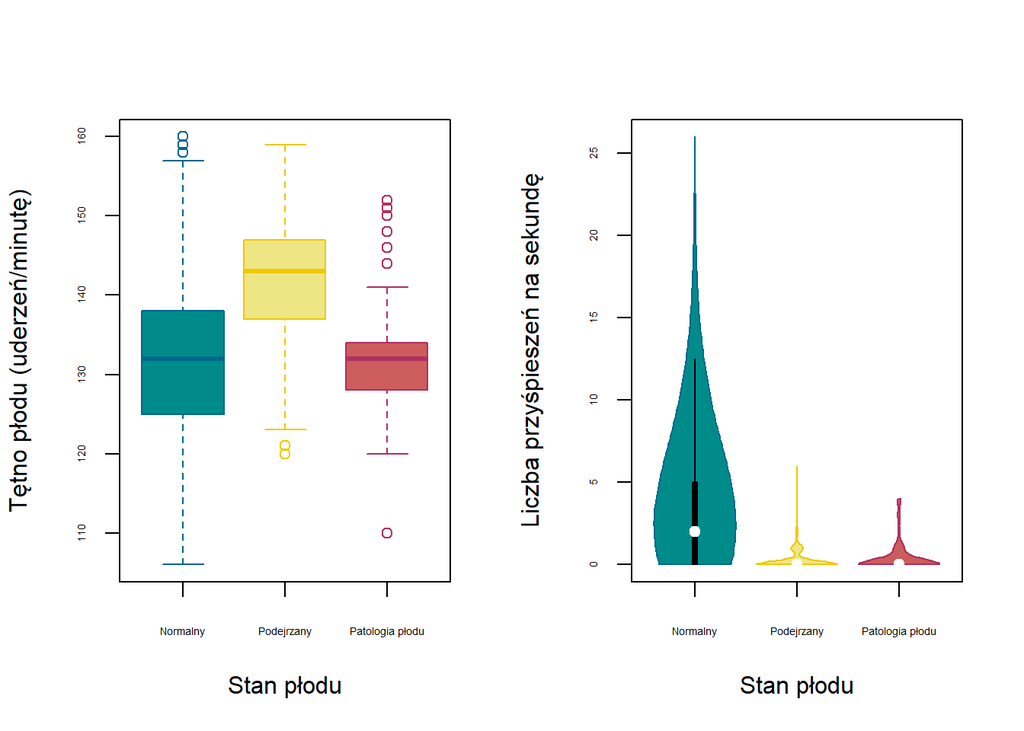

```r
par(mfrow=c(1,2))
boxplot(normal_fetal_state$LB, suspect_fetal_state$LB, pathologic_fetal_state$LB,
        ylab = "Tętno płodu (uderzeń/minutę)",
        names = c("Normalny", "Podejrzany", "Patologia płodu"),
        col=c("darkcyan", "khaki2", "indianred"), border=c("deepskyblue4","gold2","maroon"), xlab = "Stan płodu",
        cex.axis=0.45)

vioplot(normal_fetal_state$AC, suspect_fetal_state$AC, pathologic_fetal_state$AC,
        ylab = "Liczba przyśpieszeń na sekundę",
        names = c("Normalny", "Podejrzany", "Patologia płodu"),
        col=c("darkcyan", "khaki2", "indianred"), border=c("deepskyblue4","gold2","maroon"), xlab = "Stan płodu",           cex.axis=0.45)
```

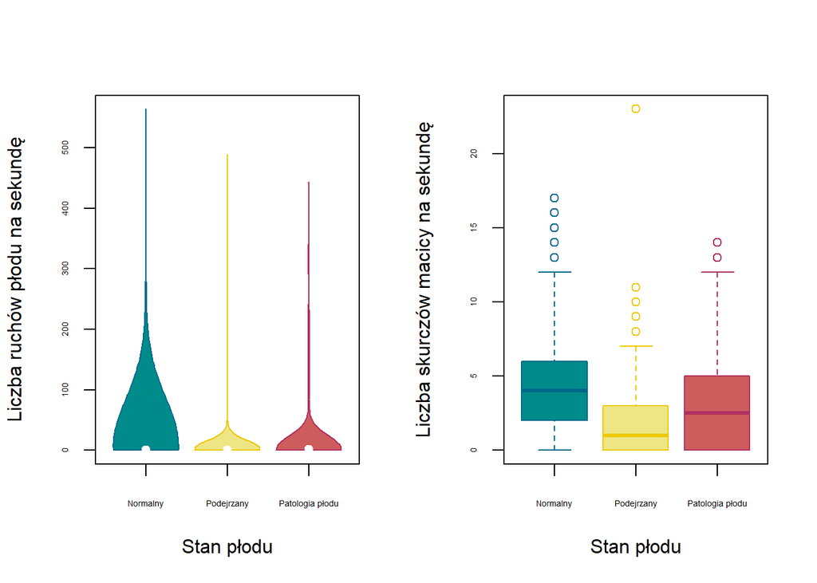

```r
par(mfrow=c(1,2))
vioplot(normal_fetal_state$FM, suspect_fetal_state$FM, pathologic_fetal_state$FM,
        ylab = "Liczba ruchów płodu na sekundę",
        names = c("Normalny", "Podejrzany", "Patologia płodu"),
        col=c("darkcyan", "khaki2", "indianred"), border=c("deepskyblue4","gold2","maroon"), xlab = "Stan płodu",
        cex.axis=0.45)
boxplot(normal_fetal_state$UC, suspect_fetal_state$UC, pathologic_fetal_state$UC,
        ylab = "Liczba skurczów macicy na sekundę",
        names = c("Normalny", "Podejrzany", "Patologia płodu"),
        col=c("darkcyan", "khaki2", "indianred"), border=c("deepskyblue4","gold2","maroon"), xlab = "Stan płodu",
        cex.axis=0.45)
```

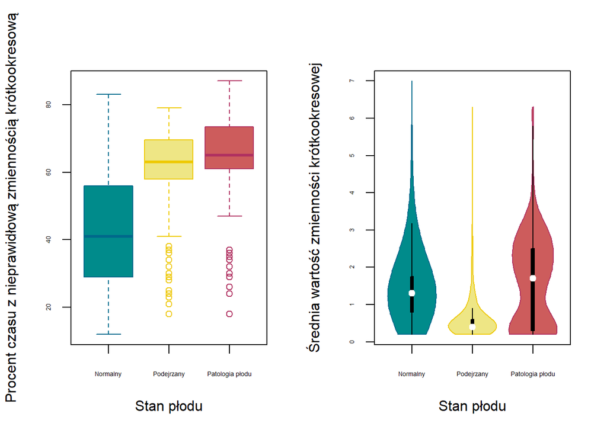

```r
par(mfrow=c(1,2))
boxplot(normal_fetal_state$ASTV, suspect_fetal_state$ASTV, pathologic_fetal_state$ASTV,
        ylab = "Procent czasu z nieprawidłową zmiennością krótkookresową",
        names = c("Normalny", "Podejrzany", "Patologia płodu"),
        col=c("darkcyan", "khaki2", "indianred"), border=c("deepskyblue4","gold2","maroon"), xlab = "Stan płodu",
        cex.axis=0.45)

vioplot(normal_fetal_state$MSTV, suspect_fetal_state$MSTV, pathologic_fetal_state$MSTV,
        ylab = "Średnia wartość zmienności krótkookresowej",
        names = c("Normalny", "Podejrzany", "Patologia płodu"),
        col=c("darkcyan", "khaki2", "indianred"), border=c("deepskyblue4","gold2","maroon"), xlab = "Stan płodu",
        cex.axis=0.45)
```

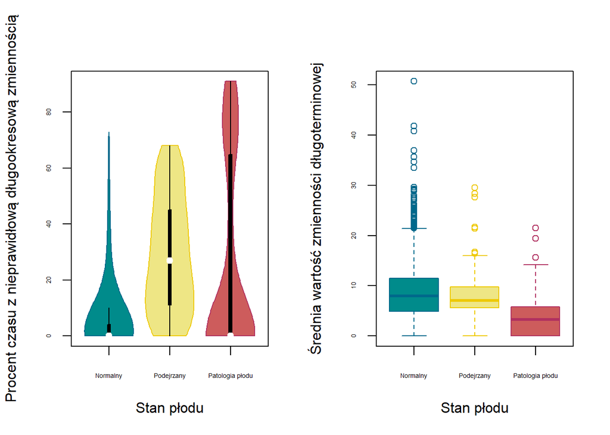

```r
par(mfrow=c(1,2))
vioplot(normal_fetal_state$ALTV, suspect_fetal_state$ALTV, pathologic_fetal_state$ALTV,
        ylab = "Procent czasu z nieprawidłową długookresową zmiennością",
        names = c("Normalny", "Podejrzany", "Patologia płodu"),
        col=c("darkcyan", "khaki2", "indianred"), border=c("deepskyblue4","gold2","maroon"), xlab = "Stan płodu",
        cex.axis=0.45)

boxplot(normal_fetal_state$MLTV, suspect_fetal_state$MLTV, pathologic_fetal_state$MLTV,
        ylab = "Średnia wartość zmienności długoterminowej",
        names = c("Normalny", "Podejrzany", "Patologia płodu"),
        col=c("darkcyan", "khaki2", "indianred"), border=c("deepskyblue4","gold2","maroon"), xlab = "Stan płodu",
        cex.axis=0.45)
```

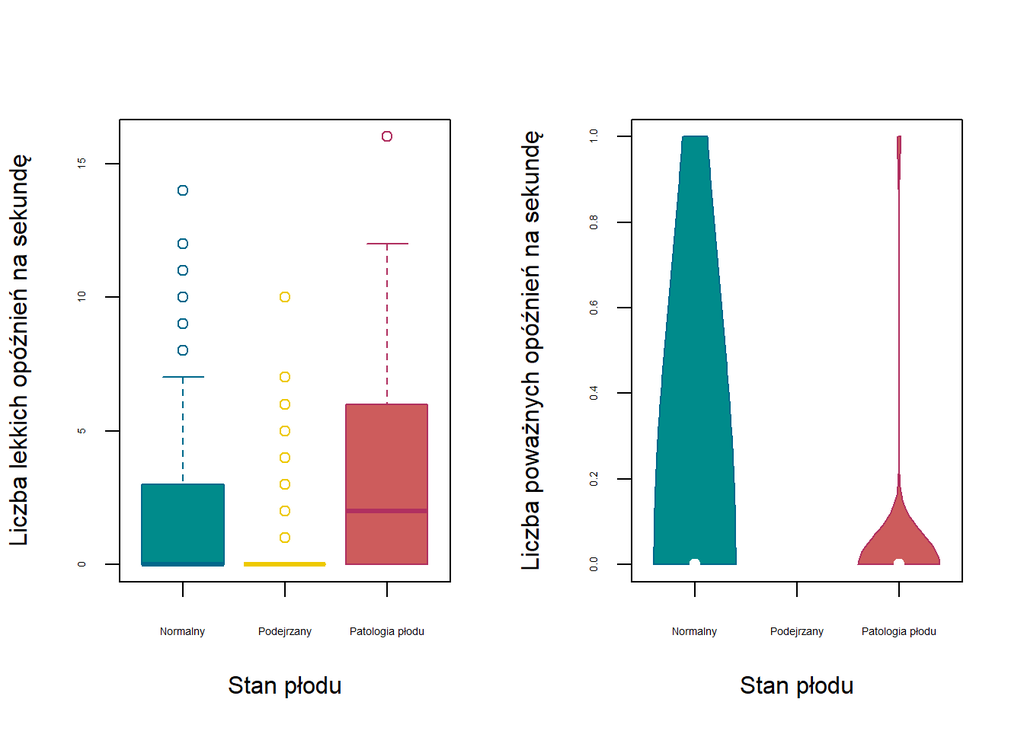

```r
par(mfrow=c(1,2))
boxplot(normal_fetal_state$DL, suspect_fetal_state$DL, pathologic_fetal_state$DL,
        ylab = "Liczba lekkich opóźnień na sekundę",
        names = c("Normalny", "Podejrzany", "Patologia płodu"),
        col=c("darkcyan", "khaki2", "indianred"), border=c("deepskyblue4","gold2","maroon"), xlab = "Stan płodu",
        cex.axis=0.45)

vioplot(normal_fetal_state$DS, suspect_fetal_state$DS, pathologic_fetal_state$DS,
        ylab = "Liczba poważnych opóźnień na sekundę",
        names = c("Normalny", "Podejrzany", "Patologia płodu"),
        col=c("darkcyan", "khaki2", "indianred"), border=c("deepskyblue4","gold2","maroon"), xlab = "Stan płodu",
        cex.axis=0.45)
```

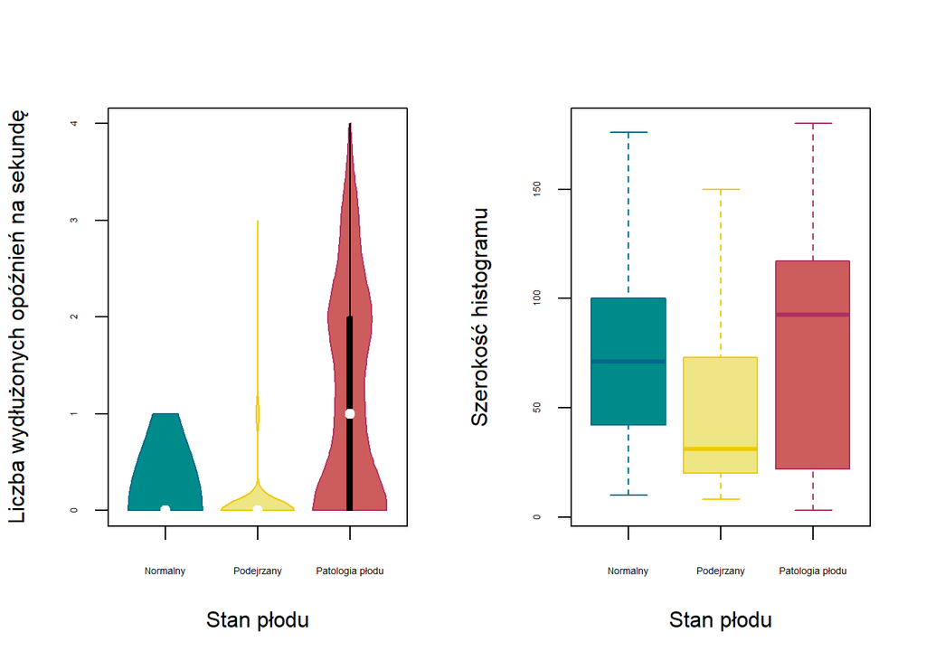

```r
par(mfrow=c(1,2))
vioplot(normal_fetal_state$DP, suspect_fetal_state$DP, pathologic_fetal_state$DP,
        ylab = "Liczba wydłużonych opóźnień na sekundę",
        names = c("Normalny", "Podejrzany", "Patologia płodu"),
        col=c("darkcyan", "khaki2", "indianred"), border=c("deepskyblue4","gold2","maroon"), xlab = "Stan płodu",
        cex.axis=0.45)

boxplot(normal_fetal_state$Width, suspect_fetal_state$Width, pathologic_fetal_state$Width,
        ylab = "Szerokość histogramu",
        names = c("Normalny", "Podejrzany", "Patologia płodu"),
        col=c("darkcyan", "khaki2", "indianred"), border=c("deepskyblue4","gold2","maroon"), xlab = "Stan płodu",
        cex.axis=0.45)
```

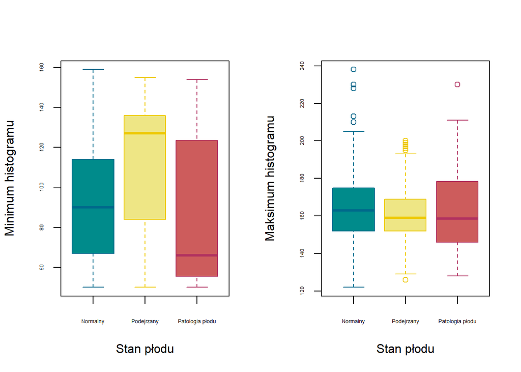

```r
par(mfrow=c(1,2))
boxplot(normal_fetal_state$Min, suspect_fetal_state$Min, pathologic_fetal_state$Min,
        ylab = "Minimum histogramu",
        names = c("Normalny", "Podejrzany", "Patologia płodu"),
        col=c("darkcyan", "khaki2", "indianred"), border=c("deepskyblue4","gold2","maroon"), xlab = "Stan płodu",
        cex.axis=0.45)

boxplot(normal_fetal_state$Max, suspect_fetal_state$Max, pathologic_fetal_state$Max,
        ylab = "Maksimum histogramu",
        names = c("Normalny", "Podejrzany", "Patologia płodu"),
        col=c("darkcyan", "khaki2", "indianred"), border=c("deepskyblue4","gold2","maroon"), xlab = "Stan płodu",
        cex.axis=0.45)
```

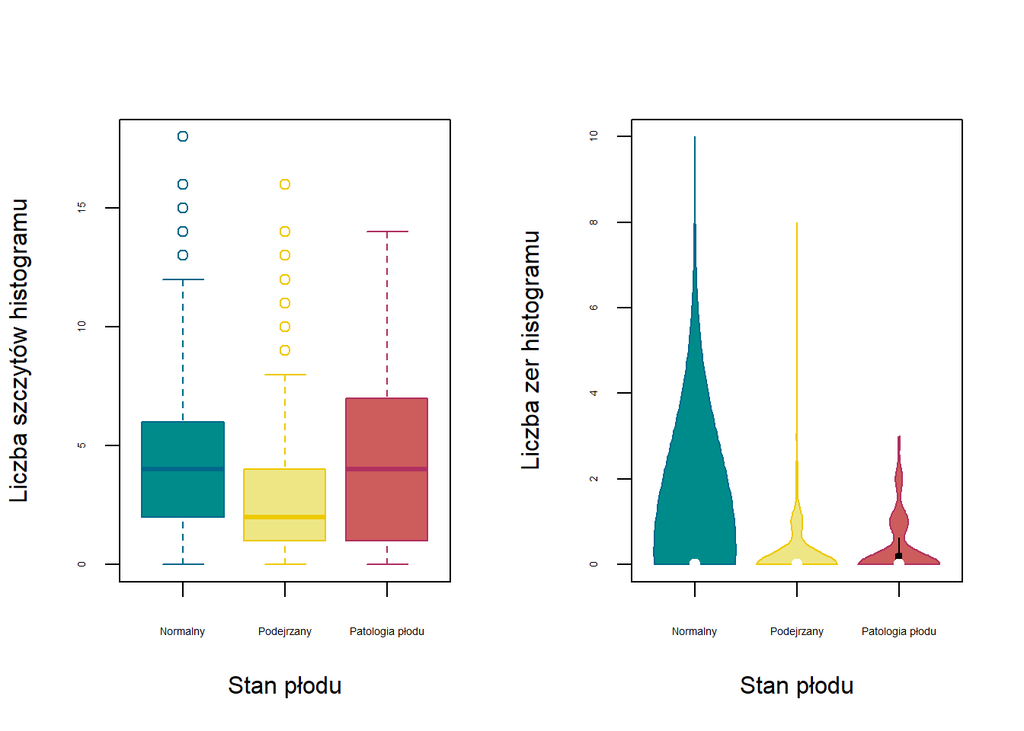

```r
par(mfrow=c(1,2))
boxplot(normal_fetal_state$Nmax, suspect_fetal_state$Nmax, pathologic_fetal_state$Nmax,
        ylab = "Liczba szczytów histogramu",
        names = c("Normalny", "Podejrzany", "Patologia płodu"),
        col=c("darkcyan", "khaki2", "indianred"), border=c("deepskyblue4","gold2","maroon"), xlab = "Stan płodu",
        cex.axis=0.45)

vioplot(normal_fetal_state$Nzeros, suspect_fetal_state$Nzeros, pathologic_fetal_state$Nzeros,
        ylab = "Liczba zer histogramu",
        names = c("Normalny", "Podejrzany", "Patologia płodu"),
        col=c("darkcyan", "khaki2", "indianred"), border=c("deepskyblue4","gold2","maroon"), xlab = "Stan płodu",
        cex.axis=0.45)
```

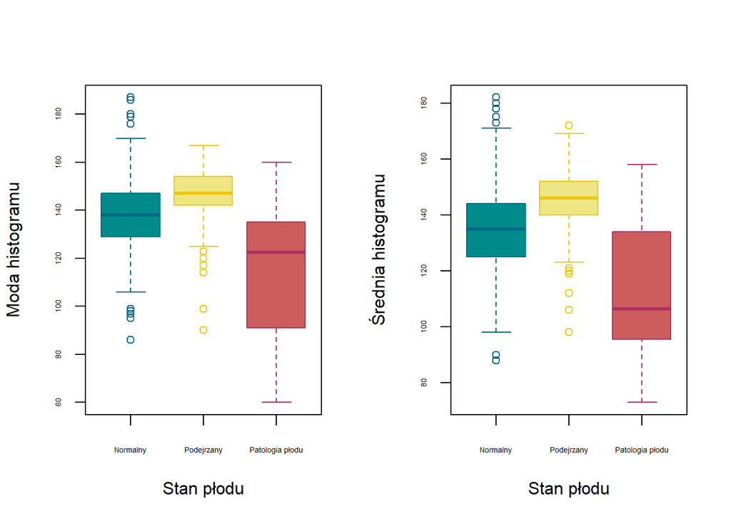

```r
par(mfrow=c(1,2))
boxplot(normal_fetal_state$Mode, suspect_fetal_state$Mode, pathologic_fetal_state$Mode,
        ylab = "Moda histogramu",
        names = c("Normalny", "Podejrzany", "Patologia płodu"),
        col=c("darkcyan", "khaki2", "indianred"), border=c("deepskyblue4","gold2","maroon"), xlab = "Stan płodu",
        cex.axis=0.45)

boxplot(normal_fetal_state$Mean, suspect_fetal_state$Mean, pathologic_fetal_state$Mean,
        ylab = "Średnia histogramu",
        names = c("Normalny", "Podejrzany", "Patologia płodu"),
        col=c("darkcyan", "khaki2", "indianred"), border=c("deepskyblue4","gold2","maroon"), xlab = "Stan płodu",
        cex.axis=0.45)
```

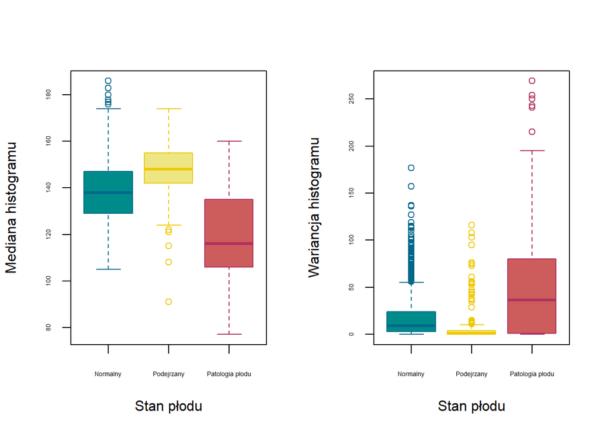

```r
par(mfrow=c(1,2))
boxplot(normal_fetal_state$Median, suspect_fetal_state$Median, pathologic_fetal_state$Median,
        ylab = "Mediana histogramu",
        names = c("Normalny", "Podejrzany", "Patologia płodu"),
        col=c("darkcyan", "khaki2", "indianred"), border=c("deepskyblue4","gold2","maroon"), xlab = "Stan płodu",
        cex.axis=0.45)

boxplot(normal_fetal_state$Variance, suspect_fetal_state$Variance, pathologic_fetal_state$Variance,
        ylab = "Wariancja histogramu",
        names = c("Normalny", "Podejrzany", "Patologia płodu"),
        col=c("darkcyan", "khaki2", "indianred"), border=c("deepskyblue4","gold2","maroon"), xlab = "Stan płodu",
        cex.axis=0.45)
```

Analizując powyższy wykres, możemy zauważyć, że konkretne parametry przyjmują zupełnie inne wartości dla poszczególnych stanów płodu.

## Model klasyfikacyjny

Biorąc pod uwagę powyższe wyniki analizy, możemy spróbować stworzyć model klasyfikacyjny, który na podstawie pozostałych parametrów, będzie przewidywać klasę zmiennej NSP, czyli kategorię stanu płodu.

Do budowy naszego modelu, wykorzystamy algorytm Random Forest.

#### Las losowy (Random Forest)

Jest to algorytm, który w pewnym sensie opiera się na konstrukcji drzew decyzyjnych. Pojedyńcze drzewo decyzyjne często nie jest zbyt dobrym modelem, o wiele lepszym rozwiązaniem jest budowa wielu drzew. Wtedy każde z drzew generuje jakieś progonozowane wartości, a następnie są one w pewien sposób łączone w jedną prognozę np. poprzez uśrednianie. Możemy odgórnie “narzucić’ ilość tychże drzew w modelu poprzez funkcję `ntree=` , jednak nie jest to konieczne, R domyślnie przyjmuje `ntree = 500`.

```r
# Ładowanie pakietu randomForest

library(randomForest)
```

#### Podział danych

```r
  set.seed(0)
  size <- nrow(CTG)
  size_percent_train <- 0.70
  subset_train <- sample(1:size, size_percent_train * size)
  train <- CTG[subset_train, ]
  test <- CTG[-subset_train, ]
```

Dopasujmy teraz nasz model do treningowego zestawu danych:

```r
model <- randomForest(x = train[-34], y = train$NSP)
model
```

```
##
## Call:
##  randomForest(x = train[-34], y = train$NSP)
##                Type of random forest: classification
##                      Number of trees: 500
## No. of variables tried at each split: 5
##
##         OOB estimate of  error rate: 1.01%
## Confusion matrix:
##      1   2   3  class.error
## 1 1161   1   0 0.0008605852
## 2   12 187   1 0.0650000000
## 3    0   1 125 0.0079365079
```

“OOB estimate of error rate” (błąd OOB (out-of-bag)) to średni błąd predykcji w każdej próbce treningowej. Prościej mówiąc: jest to odsetek wszystkich pomyłek (fałszywie pozytywnych i fałszywie negatywnych) wykonanych przez model w zbiorze treningowym.

Błąd klasyfikacji (“class.error”) stanu płodu “normalny” wynosi 0.08%, dla stanu płodu “podejrzany” wynosi 6.5%, a dla stanu “patologia płodu” wynosi 0.7%.

Teraz możemy przewidzieć wynik dla testowego zestawu danych:

```r
y_pred <- predict(model, newdata = test[-34])
```

Tablica pomyłek w zbiorze testowym:

```r
confusion_mtx <- table(test$NSP, y_pred)
confusion_mtx
```

```
##    y_pred
##       1   2   3
##   1 490   3   0
##   2   5  90   0
##   3   0   0  50
```

```r
OOB_test <- (confusion_mtx[2,1] + confusion_mtx[1,2]) / nrow(test)
```

Błąd OOB w zbiorze testowym wynosi:

```r
paste(round(OOB_test * 100, digits = 2), "%")
```

```
## [1] "1.25 %"
```

Co ważne, zdaje się, że nasz model unika pomyłek w klasyfikowaniu normalnego płodu jako patologicznego i na odwrót, co jest niezwykle istotne dla naszych rozważań.

Stwórzmy teraz wykres naszego modelu:

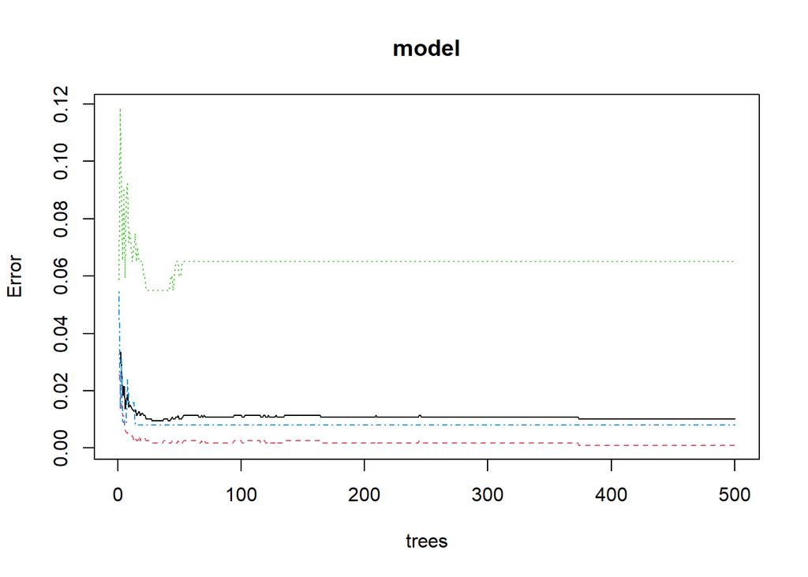

```r
plot(model)
```

Widzimy, że poziom błędu stabilizuje się wraz z rosnącą liczbą drzew.

Poniższe wartości prezentują nam to jak ważne są poszczególne zmienne:

```r
importance(model)
```

```
##          MeanDecreaseGini
## LB             7.91023599
## AC            11.24108920
## FM             2.53008613
## UC             6.48548121
## ASTV          31.86330003
## MSTV          30.56698634
## ALTV          26.50571107
## MLTV           7.87516984
## DL             2.86093770
## DS             0.09184962
## DP            12.96061121
## DR             0.00000000
## Width          9.10617231
## Min            7.32929348
## Max            5.90647770
## Nmax           3.48905721
## Nzeros         1.70974044
## Mode          15.76179380
## Mean          20.80557814
## Median        15.07120380
## Variance       9.76161477
## Tendency       1.00308716
## A             10.76161637
## B              1.81738226
## C              0.10557291
## D              0.03125046
## E             20.46162351
## AD             0.44756268
## DE             2.30994393
## LD            32.81445236
## FS            21.07753684
## SUSP          59.88958645
## CLASS        161.06811595
```

Najważniejszą zmienną jest zmienna CLASS, następnie SUSP. Pozostałe dość istotne zmienne to: MSTV, LD,ALTV, FS, ASTV, E. Przez określenie “najważniejsza zmienna” rozumiemy zmienną, która ma największy wpływ na predykcję zmiennej NSP. Obrazuje to poniższy wykres:

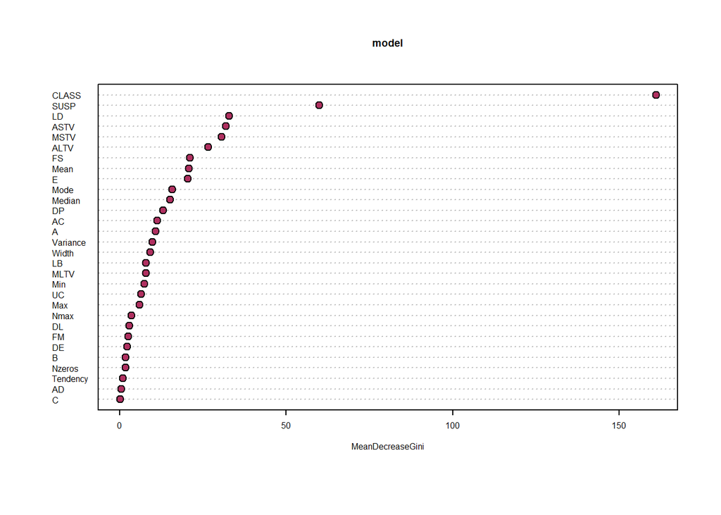

```r
# Variable importance plot
varImpPlot(model, cex=0.5, pt.cex = 1, bg="maroon" )
```